# Image analysis and classification

Image Analysis Group Geotech

June 22, 2018

## 1. Introduction

The present document has the purpose of illustrating the image analysis implementation in the programming language R project. This tutorial covers the interpretation of spectral and spatial patterns of the data as well as its classification using machine learning techniques.

## 2. Data

Wecount with two source of data, the image composition in tiff format and the smapling in shapefile.

### The raster data: Image composition of the river Aa

The raster is composed by 5 bands (1. NDVI, 2. DEM, 3. NIR, 4. Red, 5. Blue). It covers an area of 3.1 Ha and has 30 cm of spatial resolution. The source for this composition came from product of a drone fligh.The bands NIR, Red, and Blue belongs to a orthorectified multispectral image, the NDVI is calculated by using the Red and Nir infrared bands and the DSM is a Photogrammetric product.

```r
#setting work directory
setwd("D:/MASTER_GEOTECH_2S/UAS/Classification")
library(raster)
source("functions_lulc.R")
library(sf)
library(tidyverse)
```

```r
path_wd = "D:/MASTER_GEOTECH_2S/UAS/Classification"
train_data_path = "Training"
raster_data_path = "image/Compositebands30cm2.tif"
#Importing raster to obtain information about number of bands and size of the image in terms of number of pixels
composition_drone = raster(raster_data_path)
nbands = composition_drone@file@nbands  #Number of bands
#Empty list with 5 elements where I will store each raster
bands_list = vector("list",nbands)
#Using for loop to store the bands in the list
for(i in 1:nbands)
{
  bands_list[[i]] = raster(raster_data_path,band = i)
}
#stacking raster
bands_data <- stack(bands_list)
```

### The training data

The training data is composed by 8 shapefiles. Each file contains the sampling by each class to characterize the area(see below). Each sampling comes in a square shape and measures 50 cm by side covering in average 4 pixels by square. In the next lines, we will import the shapefiles to the environment of R and we will mask the pixels that intersect each group of squares by band.

```r
#Creating a list and a for loop to store the name of the shapefiles that are contained in the training folder
files_shp = list()
i= 1
for(f in list.files(train_data_path)){
    x = substr(f,nchar(f)-3,nchar(f))
    if( x == ".shp"){
      files_shp[i] = paste(train_data_path,f,sep="/")
      i = i + 1
    }
}
#Creating masks with the polygons of the training
dataset = labeling_vector(files_shp,bands_data) %>% as.data.frame()
#data set with the results of the raster mask
colnames(dataset) = c("x","y","NDVI","DSM","NIR","RED","BLUE","Label")
```

Once created the dataset that contains the coordinates, class and corresponding value of the bands by each pixel, our next task is to see how is distributed the sampling by each class.

```r
t_samples = table(dataset$Label)
names(t_samples) = c("Asphalt(1)", "Bare_soil(2)", "Bushes(3)", "freshlyCutgrass(4)","Grasslands(5)", "Trees(6)","Water(7)","veg_water(8)" )
print(t_samples)
```

```
##         Asphalt(1)       Bare_soil(2)          Bushes(3)
##                 31                 32                 96
## freshlyCutgrass(4)      Grasslands(5)           Trees(6)
##                114                141                 78
##           Water(7)       veg_water(8)
##                 38                 16
```

```r
#converting to sf class
samples_sf = st_as_sf(dataset, coords = c("x", "y"), crs = 32632)
```

## 3. Exploration

Once imported the data in R project, we can visualize the composition by bands and overlap the training.

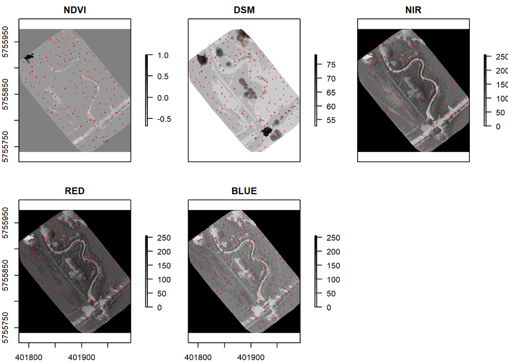

```r
fun <- function() {
plot(st_geometry(samples_sf), add = TRUE, col = "red", pch = 1, cex =0.2)
}
plot(bands_data,addfun = fun, col= grey((9:0)/10), main=c("NDVI","DSM","NIR","RED","BLUE"))
```

The range of pixel values for red, blue and near infrared is measured in digital levels, with a range that goes from 85 to 219 for the red, from 37 to 200 for the NIR and from 28 to 154 in the blue. Moreover, the NDVI is an index with a range of values between -0.52 and -0.025 and the DSM from 53 to 78 meters. The boxplot also shows the range of values of each variable, however, this graphic also shows the variance and existence of outliers in the sampling.

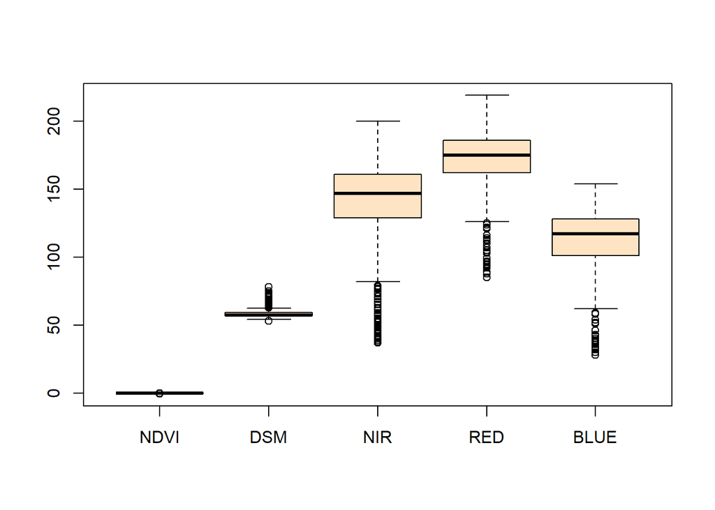

```r
boxplot(dataset[,3:7],col= "bisque")
```

### Understanding patterns in the data

The figure 3 presents the scatter plots with the bands values of the dataset. Essentially, the graphic is showing in the bottom left the dispersion among the values of the 5 bands, and in the top right their respective correlation coefficients. It should be noticed, that colors represent the classes associated to each component of pixel values in the dataset. For example, the brown points, in the graphic NDVI vs DSM, correspond to trees and they are located in the higuest range of the dispersion. This information will be very valuable for the classifier since elevation will be the criteria to separate bushes from trees and grass regardless of whether they reflect the sunlight in similar way.

For NIR an Red we found a strong linear correlation when it comes about vegetation coverages. However, classes such as water, bare soil and asphalt can be separated visually since the belong to the lowest region of the dispersion. This fact can be better explored using NDVI in one of the axis and NIR in the another since the decision of defining what is or not vegetation is a straing line perpendicular to the NIR axis.

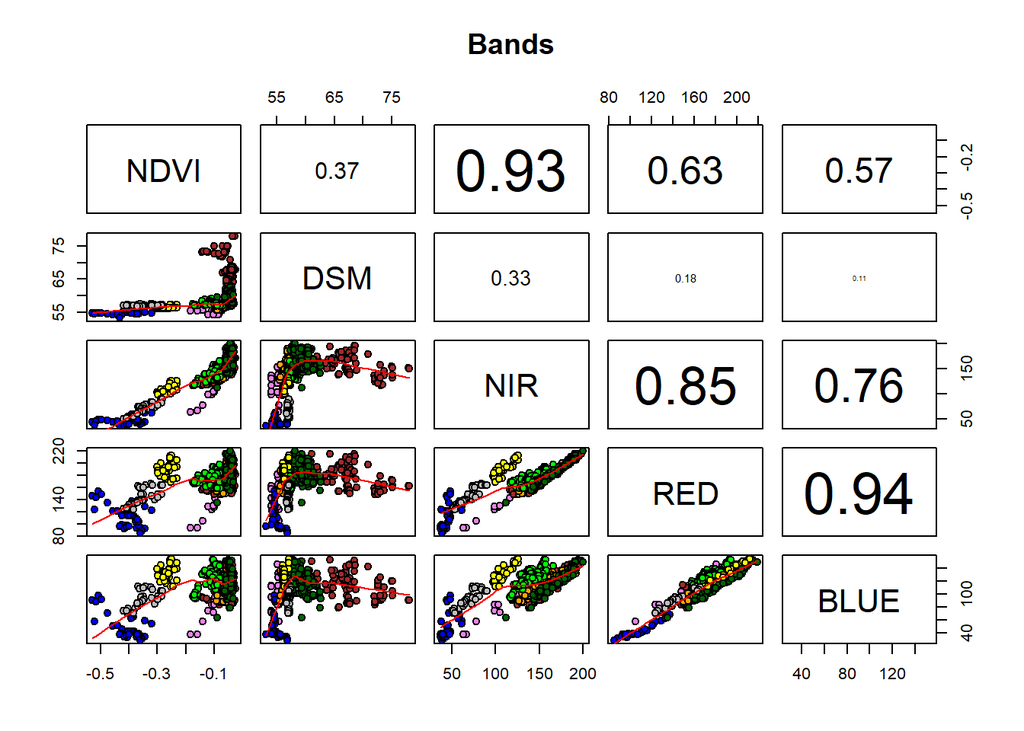

```r
pairs(dataset[,3:7], main = "Bands",
      pch = 21, bg =c("grey","yellow","darkgreen","green","orange","brown","blue","violet")[unclass(dataset$Label)],
      lower.panel = panel.smooth, upper.panel = panel.cor)
```

## Classification

### Partitioning dataset

The quality of the image classification will depend in how accurate the predictor is in classifying our dataset. Therefore, for this task, we will start separating our data in two sets, one to train the classifier (70%) and another to test it (30%). This selection is random.

```r
#data partition
dataset$Label = as.factor(dataset$Label)
#set.seed function makes this analysis repetitible. So we want to work with the same random sampling.
set.seed(123)
#this produce a random number of indices and divide it in two groups.
ind =  sample(2,nrow(dataset), replace =TRUE, prob = c(0.7,0.3))
train = dataset[ind==1,]
testd = dataset[ind==2,]
```

### Classifiers

We run two classifiers using the same dataset, they are random forest and support vector machine.

#### Random forest

In the next lines we will train the classsifier using the 70% of the dataset.

```r
library(caret)
library(randomForest)
```

```r
rf = randomForest::randomForest(Label~. , data = train[,c(-1,-2)],
                                ntree = 500,
                                mtry = 2)
#print(rf)
importance(rf)
```

```
##      MeanDecreaseGini
## NDVI         84.95702
## DSM         124.72759
## NIR          51.16535
## RED          26.06540
## BLUE         31.43046
```

“Importance” function extracts by order the level of importance of the variable in the prediction. In this sense, DSM and NDVI are essential in the classification problem.

Once trained the classifier we assess the results using the rest of the data

```r
p1 = predict(rf, testd[,c(-1,-2,-8)])
caret::confusionMatrix(p1,testd$Label)
```

```
## Confusion Matrix and Statistics
##
##           Reference
## Prediction  1  2  3  4  5  6  7  8
##          1 12  0  0  0  0  0  0  0
##          2  0  9  0  0  0  0  0  0
##          3  0  0 26  0  0  0  0  0
##          4  0  0  0 33  0  0  0  0
##          5  0  0  0  3 37  1  0  2
##          6  0  0  0  0  0 21  0  0
##          7  0  0  0  0  0  0 10  0
##          8  0  0  0  0  0  0  0  4
##
## Overall Statistics
##
##                Accuracy : 0.962
##                  95% CI : (0.9192, 0.9859)
##     No Information Rate : 0.2342
##     P-Value [Acc > NIR] : < 2.2e-16
##
##                   Kappa : 0.9542
##  Mcnemar's Test P-Value : NA
##
## Statistics by Class:
##
##                      Class: 1 Class: 2 Class: 3 Class: 4 Class: 5 Class: 6
## Sensitivity           1.00000  1.00000   1.0000   0.9167   1.0000   0.9545
## Specificity           1.00000  1.00000   1.0000   1.0000   0.9504   1.0000
## Pos Pred Value        1.00000  1.00000   1.0000   1.0000   0.8605   1.0000
## Neg Pred Value        1.00000  1.00000   1.0000   0.9760   1.0000   0.9927
## Prevalence            0.07595  0.05696   0.1646   0.2278   0.2342   0.1392
## Detection Rate        0.07595  0.05696   0.1646   0.2089   0.2342   0.1329
## Detection Prevalence  0.07595  0.05696   0.1646   0.2089   0.2722   0.1329
## Balanced Accuracy     1.00000  1.00000   1.0000   0.9583   0.9752   0.9773
##                      Class: 7 Class: 8
## Sensitivity           1.00000  0.66667
## Specificity           1.00000  1.00000
## Pos Pred Value        1.00000  1.00000
## Neg Pred Value        1.00000  0.98701
## Prevalence            0.06329  0.03797
## Detection Rate        0.06329  0.02532
## Detection Prevalence  0.06329  0.02532
## Balanced Accuracy     1.00000  0.83333
```

Looking at the confusion matrix, predictions are quite good in general with an overall accuracy of 96%. One of the main reasons of this result is because the training had intervation in areas with shadows. Before having these results the accuracy did not overcome the 79% (that was also quite good). However, once we removed the training over shadows the accuracy increased up to 96%.

### SVM

We run support vector machine using the package called e1071. We use the same number of variables and the same partition of the dataset. We tune two conditions of the classifier, they are the parameters, epsilon in the insensitive-loss function and and the cost of constraints violation. We use by default the radial kernel since is the one giving the best results.

```r
library(e1071)
```

```r
svm_model1 = e1071::svm(Label~. , data = train[,c(-1,-2)], kernel='radial')
#tunning parameters
tmodel = tune(svm,Label~. , data = train[,c(-1,-2)],
              ranges = list(epsilon = seq(0,1,0.1), cost = seq(20,40,4)))
#plot(tmodel )
#summary(tmodel)
svm_model2 = tmodel$best.model
#summary(mymodel)

p2 = predict(svm_model2, testd[,c(-1,-2,-8)])
caret::confusionMatrix(p2,testd$Label)
```

```
## Confusion Matrix and Statistics
##
##           Reference
## Prediction  1  2  3  4  5  6  7  8
##          1 12  0  0  0  0  0  0  0
##          2  0  9  0  0  0  0  0  0
##          3  0  0 26  0  0  0  0  0
##          4  0  0  0 36  3  0  0  0
##          5  0  0  0  0 34  1  0  0
##          6  0  0  0  0  0 21  0  0
##          7  0  0  0  0  0  0 10  0
##          8  0  0  0  0  0  0  0  6
##
## Overall Statistics
##
##                Accuracy : 0.9747
##                  95% CI : (0.9365, 0.9931)
##     No Information Rate : 0.2342
##     P-Value [Acc > NIR] : < 2.2e-16
##
##                   Kappa : 0.9696
##  Mcnemar's Test P-Value : NA
##
## Statistics by Class:
##
##                      Class: 1 Class: 2 Class: 3 Class: 4 Class: 5 Class: 6
## Sensitivity           1.00000  1.00000   1.0000   1.0000   0.9189   0.9545
## Specificity           1.00000  1.00000   1.0000   0.9754   0.9917   1.0000
## Pos Pred Value        1.00000  1.00000   1.0000   0.9231   0.9714   1.0000
## Neg Pred Value        1.00000  1.00000   1.0000   1.0000   0.9756   0.9927
## Prevalence            0.07595  0.05696   0.1646   0.2278   0.2342   0.1392
## Detection Rate        0.07595  0.05696   0.1646   0.2278   0.2152   0.1329
## Detection Prevalence  0.07595  0.05696   0.1646   0.2468   0.2215   0.1329
## Balanced Accuracy     1.00000  1.00000   1.0000   0.9877   0.9553   0.9773
##                      Class: 7 Class: 8
## Sensitivity           1.00000  1.00000
## Specificity           1.00000  1.00000
## Pos Pred Value        1.00000  1.00000
## Neg Pred Value        1.00000  1.00000
## Prevalence            0.06329  0.03797
## Detection Rate        0.06329  0.03797
## Detection Prevalence  0.06329  0.03797
## Balanced Accuracy     1.00000  1.00000
```

### Mapping classification

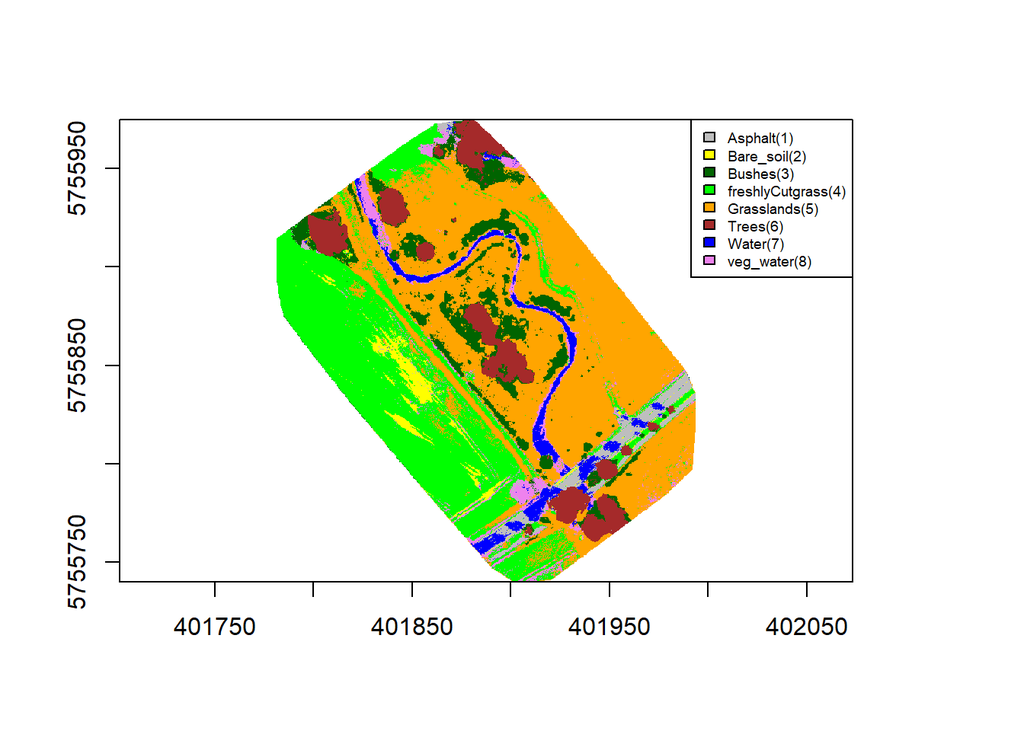

```r
dataset_bands = values(bands_data)
colnames(dataset_bands) = c("NDVI","DSM","NIR","RED","BLUE")
p3 = predict(rf, dataset_bands)  %>% as.numeric()
new_raster = bands_list[[1]]
values(new_raster) = p3
col_fun = c("grey","yellow","darkgreen","green","orange","brown","blue","violet")
plot(new_raster, col =  col_fun, legend= FALSE)
legend("topright", legend = names(t_samples), fill = col_fun, cex = 0.6)
```

```r
#writeRaster(new_raster,"image/classification_inR.tif")
```